# p8105_hw5_ej2520

Erynne Jackson

2024-11-15

# Problem 1

```r
birth_sim = function(n){
birthday = sample(1:365, size = n, replace = TRUE)

duplicate = length(unique(birthday)) < n

return(duplicate)

}

birth_sim(50)
```

```
## [1] TRUE
```

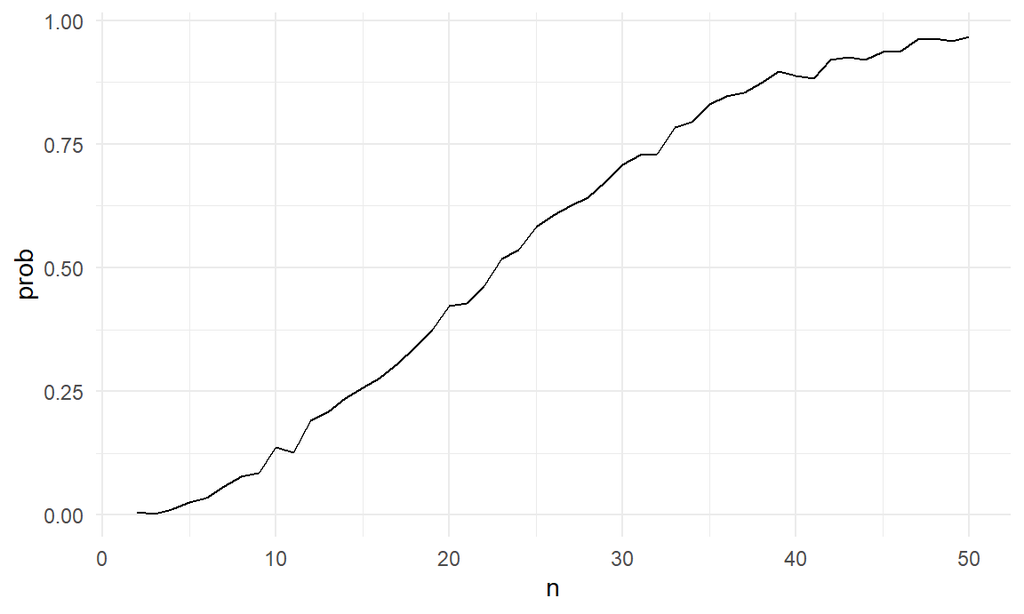

```r
sim_res =
  expand_grid(
    n = 2:50,
    iter = 1:1000
  ) |>
  mutate(res = map_lgl(n, birth_sim)) |>
group_by(n) |>
summarize(prob = mean(res))


sim_res |>
  ggplot(aes(x = n, y=prob)) +
  geom_line()
```

# Problem 2

```r
Power_data = tibble(
  x = rnorm(30,0,5)
)

Power_data |>
  summarize(
    mean_x= mean(x),
    sd_x= sd(x)
  )
```

```
## # A tibble: 1 × 2
##   mean_x  sd_x
##    <dbl> <dbl>
## 1 -0.644  4.69
```

```r
power = function(n) {
  sim_data = rnorm(n, 0, 5)
  return(tibble(mean_x = mean(sim_data), sd_x = sd(sim_data)))
}


output = vector("list", 5000)
for (i in 1:5000) {
  output[[i]] = power(30)
}

sim_res = bind_rows(output)
```

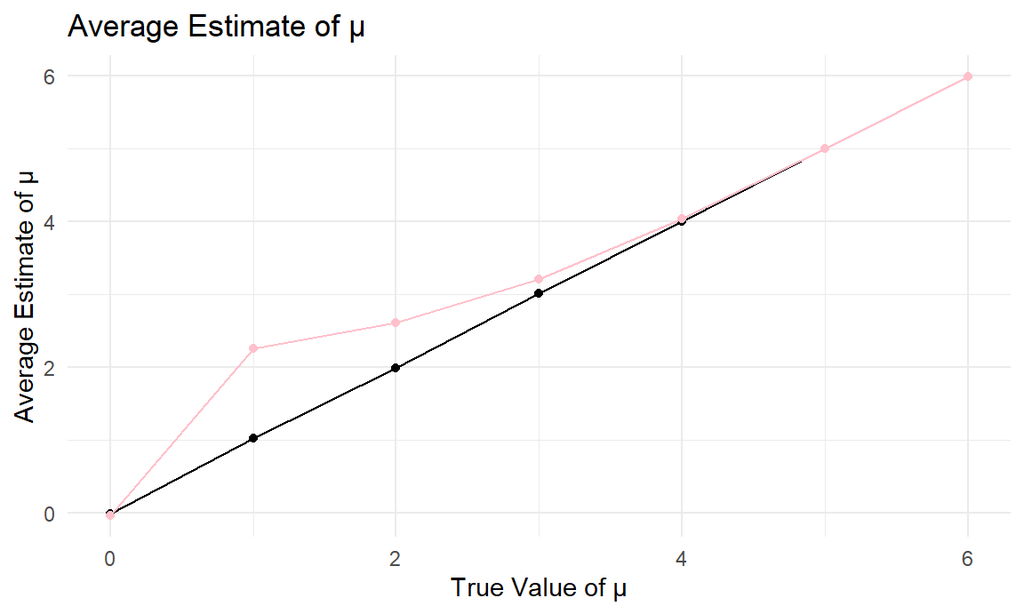

```r
n = 30
sigma = 5
alpha = 0.05
num_sim = 5000
mu_values = c(0,1,2,3,4,5,6)

output = vector("list",.100)

for(mu in mu_values) {
  estimates = numeric(num_sim)
  p_values = numeric(num_sim)


  for(i in 1:5000) {
    x <- rnorm(n, mean = mu, sd = sigma)

    test_res = t.test(x, mu = 0)
    estimates[i] = test_res$estimate
    p_values[i] = test_res$p.value
  }


  power = mean(p_values < alpha)
  avg_est = mean(estimates)
  avg_est_rejected = mean(estimates[p_values < alpha])


output[[as.character(mu)]] = list(
    power = power,
    avg_est= avg_est,
    avg_est_rejected = avg_est_rejected
  )
}

final_test = data.frame(
  mu = rep(mu_values, each = 1),
  power = sapply(output, function(x) x$power),
  avg_est= sapply(output, function(x) x$avg_est),
  avg_est_rejected = sapply(output, function(x) x$avg_est_rejected)
)


power.true = ggplot(final_test, aes(x = mu, y = power)) +
  geom_line() +
  geom_point() +
  labs(title = "Power of the Test",
       x = "True Value of μ",
       y = "Proportion Rejected (Power)")


average.true = ggplot(final_test, aes(x = mu, y = avg_est)) +
  geom_line() +
  geom_point() +
  labs(title = "Average Estimate of μ",
       x = "True Value of μ",
       y = "Average Estimate of μ") +
  geom_line(aes(x = mu, y = avg_est_rejected), color = "pink") +
  geom_point(aes(x = mu, y = avg_est_rejected), color = "pink")

# Print the results
print(average.true)
```

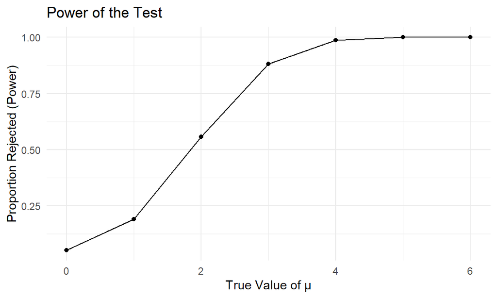

```r
print(power.true)
```

# Problem 3

The raw homicide dataset contains 52,179 observations and 12 columns/variables that gives us information on homicides in 50 large U.S cities . The variables are `uid`, `reported_data`, `victim_last`, `victim_race`, `victim_age`, `victim_sex`, `city`, `state`, `lat`, `lon`, and ’`disposition`. Below, I have added a new variable that combined city and state.

```r
homicide = read_csv("homicide-data.csv")
new_homicide = homicide|>
  mutate(city_state = paste(city, state, sep = ",")) |>
  group_by(city_state) |>
  summarize(
    total_homicides = n(),
    unsolved_homicides = sum(disposition %in% c("Closed without arrest", "Open/No arrest")),
    .groups = "drop"
  )
```

Next, I obtained the proportion on homicides that were unsolved and pulled the estimate and confidence interval.

```r
baltimore_data = homicide |>
  mutate(city_state = paste(city, state, sep = ",")) |>
  filter(city_state == "Baltimore,MD") |>
  summarize(
    total_homicides_balt = n(),
    unsolved_homicides_balt = sum(disposition %in% c("Closed without arrest", "Open/No arrest"), na.rm = TRUE))

baltimore_prop =
  prop.test(baltimore_data$unsolved_homicides_balt, baltimore_data$total_homicides_balt) |>
  broom::tidy()

print(baltimore_prop)
```

```
## # A tibble: 1 × 8
##   estimate statistic  p.value parameter conf.low conf.high method    alternative
##      <dbl>     <dbl>    <dbl>     <int>    <dbl>     <dbl> <chr>     <chr>
## 1    0.646      239. 6.46e-54         1    0.628     0.663 1-sample… two.sided
```

Below, I pulled he estimate and confidence interval for every city in our homicide dataset.

```r
new_homicide = homicide|>
  mutate(city_state = paste(city, state, sep = ",")) |>
  group_by(city_state) |>
  summarize(
    total_homicides = n(),
    unsolved_homicides = sum(disposition %in% c("Closed without arrest", "Open/No arrest")),
    .groups = "drop"
  )


prop_every_city = new_homicide |>
  mutate(
    prop_result = pmap(
      list(unsolved_homicides, total_homicides),
      ~ prop.test(..1, ..2))) |>
   mutate(
    prop_tidy = map(prop_result, broom::tidy)) |>
  unnest(prop_tidy) |>
  select(city_state, estimate, p.value, conf.low, conf.high)

print(prop_every_city)
```

```
## # A tibble: 51 × 5
##    city_state     estimate   p.value conf.low conf.high
##    <chr>             <dbl>     <dbl>    <dbl>     <dbl>
##  1 Albuquerque,NM    0.386 1.23e-  5    0.337     0.438
##  2 Atlanta,GA        0.383 4.32e- 13    0.353     0.415
##  3 Baltimore,MD      0.646 6.46e- 54    0.628     0.663
##  4 Baton Rouge,LA    0.462 1.32e-  1    0.414     0.511
##  5 Birmingham,AL     0.434 2.05e-  4    0.399     0.469
##  6 Boston,MA         0.505 8.40e-  1    0.465     0.545
##  7 Buffalo,NY        0.612 3.73e-  7    0.569     0.654
##  8 Charlotte,NC      0.300 1.41e- 25    0.266     0.336
##  9 Chicago,IL        0.736 1.28e-269    0.724     0.747
## 10 Cincinnati,OH     0.445 4.41e-  3    0.408     0.483
## # ℹ 41 more rows
```

Finally, I created a plot that graphs the estimate for each city with error bars.

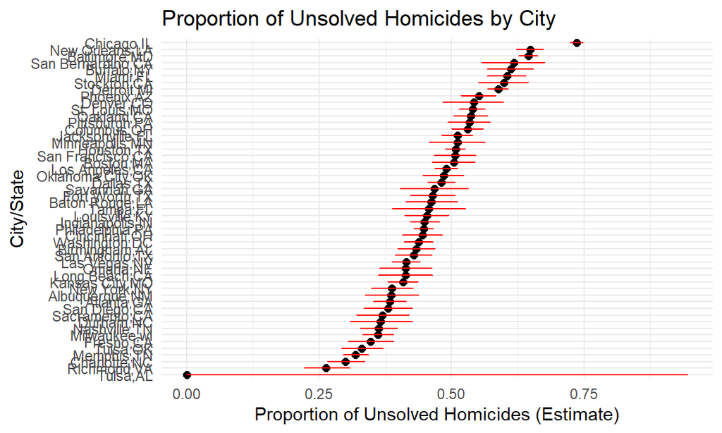

```r
prop_plot = prop_every_city |>
  mutate (city_state = fct_reorder(city_state, estimate)) |>
  ggplot(aes(x = city_state, y = estimate, ymin = conf.low, ymax = conf.high)) +
  geom_point(color = "black", size = 2) +
  geom_errorbar(width = 0.1, color = "red") +
  labs(
    x = "City/State",
    y = "Proportion of Unsolved Homicides (Estimate)",
    title = "Proportion of Unsolved Homicides by City"
  ) +
  coord_flip() +
  theme_minimal()

print(prop_plot)
```